Compiling data on the novel coronavirus (covid-19) in Sierra Leone Tom Dorrington Ward Last update: 10 June 2020

# 1 Introduction

This notebook describes the steps taken to compile data relating to coronavirus (covid-19), demographics, and households’ main sources of information in Sierra Leone, and convert it into “tidy” format.

It performs only a very limited number of operations to *change* the data:

- It does not make any assumptions to fill in missing values.
- It corrects only *one* value which appears to be incorrect. As the section District-Level Main Source of Information Data illustrates, the total number of households in Western Area Urban in the sources of information data is missing a final “1”, and should be “229951” instead of “22995”.

There are several other anomalies, such as *downward* revisions to the cumulative number of cases and, for the country-level data, duplicate date-time stamps and inconsistencies between different statistical series. I leave the user of the data to decide how to resolve these issues in their analysis.

For this notebook, I use R and the [tidyverse](https://www.tidyverse.org/) collection of packages to produce datasets for use in data visualisation and analysis.

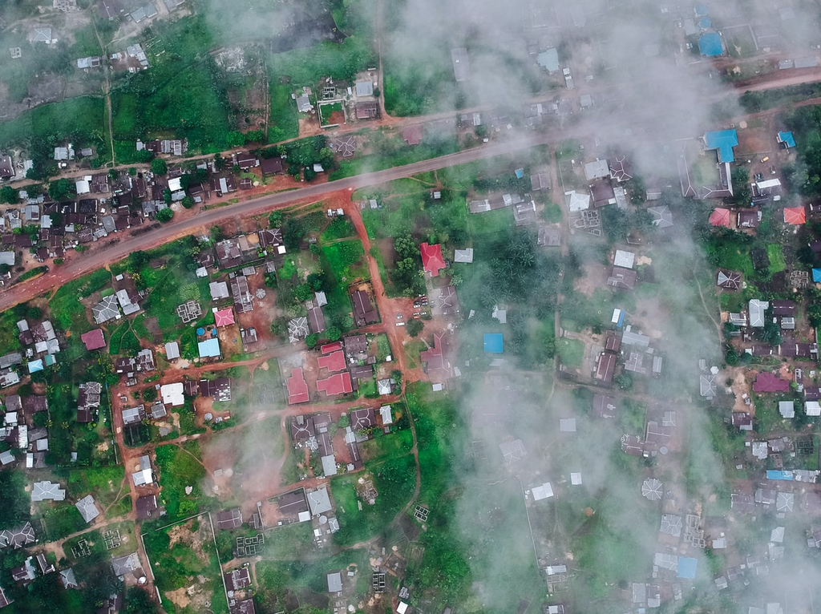

Bo, Sierra Leone.  
*Photo credit:* [Joshua Hanson/Unsplash.com](https://unsplash.com/s/photos/bo%2C-sierra-leone)

# 2 Importing Libraries

First, we import the packages required to display and prepare the data:

```r
if(!require(knitr)) install.packages("knitr", repos = "http://cran.us.r-project.org")
if(!require(kableExtra)) install.packages("kableExtra", repos = "http://cran.us.r-project.org")
if(!require(tidyverse)) install.packages("tidyverse", repos = "http://cran.us.r-project.org")
if(!require(lubridate)) install.packages("lubridate", repos = "http://cran.us.r-project.org")
```

# 3 Data Sources

## 3.1 Data on Coronavirus, Demographics and Main Sources of Information

Next, we set the references for the data sources relative to the base repository for this project. All input data are stored in the `input` folder, whilst the final tidy data are in the `output` folder.

```r
#---- Inputs ----
INPUT_PATH <- "./input/"
# source: https://covid19.mic.gov.sl/ then https://covid19.mic.gov.sl/districts.beade2ed.csv
CV_DISTRICT <- "districts.beade2ed.csv"
# source: https://covid19.mic.gov.sl/ then https://covid19.mic.gov.sl/stats.e46e07fd.csv
CV_NATIONAL <- "stats.e46e07fd.csv"
# source: https://opendatasl.gov.sl/dataset/population-distribution-district
POP_DISTRICT <- "Population Distribution by District.csv"
# source: https://opendatasl.gov.sl/dataset/households-main-source-information-district
INFO_DISTRICT <- "Main sources of information.csv"

#---- Outputs ----
OUTPUT_PATH <- "./output/"
CV_DISTRICT_OUT <- "sl_districts_coronavirus.csv"
POP_DISTRICT_OUT <- "sl_districts_demographics.csv"
INFO_DISTRICT_OUT <- "sl_districts_info_sources.csv"
CV_NATIONAL_OUT <- "sl_national_coronavirus.csv"
```

The source datasets are:

**1. Coronavirus Cumulative Confirmed Cases at the District Level** (“districts.beade2ed.csv”, last accessed 10 June 2020). I found the address of this file by looking in the `static/js/data` folder in the source code for covid19.mic.gov.sl. The file contains the cumulative number of confirmed coronavirus cases in each of the 16 districts in Sierra Leone as a time series, where some dates are missing.

```r
read_csv(file.path(INPUT_PATH, CV_DISTRICT)) %>% head() %>% kable() %>% kable_styling(full_width=F, font_size = 11)
```

| date | bo | bonthe | bombali | falaba | kailahun | kambia | karene | kono | kenema | koinadugu | moyamba | portloko | pujehun | tonkolili | western rural | western urban |
| --- | --- | --- | --- | --- | --- | --- | --- | --- | --- | --- | --- | --- | --- | --- | --- | --- |
| 2020-04-26 11:00:00 | 0 | 0 | 1 | 0 | 0 | 0 | 0 | 0 | 3 | 0 | 0 | 6 | 0 | 0 | 15 | 77 |
| 2020-04-27 11:00:00 | 0 | 0 | 1 | 0 | 0 | 0 | 0 | 0 | 3 | 0 | 0 | 6 | 0 | 0 | 15 | 77 |
| 2020-04-28 11:00:00 | 0 | 0 | 1 | 0 | 0 | 0 | 0 | 0 | 3 | 0 | 0 | 6 | 0 | 2 | 15 | 77 |
| 2020-05-01 11:00:00 | 0 | 10 | 6 | 0 | 0 | 0 | 0 | 0 | 4 | 0 | 0 | 7 | 0 | 3 | 19 | 87 |
| 2020-05-02 11:00:00 | 0 | 10 | 6 | 0 | 0 | 0 | 0 | 0 | 5 | 0 | 0 | 7 | 0 | 3 | 24 | 100 |
| 2020-05-03 11:00:00 | 1 | 10 | 6 | 0 | 0 | 0 | 0 | 0 | 6 | 0 | 0 | 7 | 0 | 3 | 24 | 100 |

**2. Coronavirus at the Country Level** (“stats.e46e07fd.csv”, last accessed 10 June 2020). As for the previous dataset, I found the address of this file by looking in the `static/js/data` folder in the source code for covid19.mic.gov.sl. This file contains numerous statistics relating to coronavirus, each as a time series with missing dates. It includes:

- The number of new cases (`new case`)
- The cumulative number of confirmed cases (`confirmed cases`)
- The cumulative number of individuals who have recovered (`recovered`)
- The number of individuals in isolation centres (`At Isolation Centres`)
- The number of individuals in quarantine (`in quarantine`)
- The number of individuals out of quarantine (`out of quarantine`)
- The number of females (`female`), presumably confirmed cases though this is unclear
- The number of males (`male`), presumably confirmed cases though this is unclear

I note that at the start of the period the data are not reliable, since the total number of confirmed cases decreases before increasing again. There are duplicate date entries and there also appear to be inconsistencies between the different statistics, for instance `female` + `male` does not equal `confirmed cases`.

```r
read_csv(file.path(INPUT_PATH, CV_NATIONAL)) %>% head() %>% kable() %>% kable_styling(full_width=F, font_size=11)
```

| date | new case | confirmed cases | At Isolation Centres | recovered | death | in quarantine | out of quarantine | female | male |
| --- | --- | --- | --- | --- | --- | --- | --- | --- | --- |
| 2020-04-26 11:00:00 | 7 | 79 | NA | 10 | 3 | 889 | 93 | 45 | 58 |
| 2020-04-27 11:00:00 | 6 | 5 | NA | 10 | 4 | 1187 | 99 | 49 | 50 |
| 2020-04-28 11:00:00 | 5 | 8 | NA | 12 | 4 | 1192 | 104 | 49 | 51 |
| 2020-04-29 11:00:00 | 5 | 104 | 88 | 12 | 4 | 1192 | 1139 | 49 | 51 |
| 2020-04-30 11:00:00 | 12 | 116 | 98 | 14 | 4 | 1166 | 1426 | 55 | 61 |
| 2020-05-01 11:00:00 | 8 | 124 | 96 | 21 | 7 | 1166 | 1448 | 58 | 68 |

**3. Demographics at the District Level:** Data from the 2015 Population and Housing Census (PHC), sourced from [Open Data Sierra Leone](https://opendatasl.gov.sl/dataset/population-distribution-district). The dataset covers the 14 districts of Sierra Leone, which increased to 16 in 2017. Last accessed 2 June 2020.

```r
read_csv(file.path(INPUT_PATH, POP_DISTRICT)) %>% head() %>% kable() %>% kable_styling(full_width=F, font_size = 11)
```

| District | D Code | D ID | Total Pop | Pop Share | T Male | T Female | S Ratio | T Rural | T Urban | Prop Urban | T H Pop | H Male | H Female | T I Pop | I Male | I Female | Working Pop | Depend Pop |
| --- | --- | --- | --- | --- | --- | --- | --- | --- | --- | --- | --- | --- | --- | --- | --- | --- | --- | --- |
| Kailahun | SLE0101 | 3230901 | 526379 | 7.4 | 260586 | 265793 | 97.9 | 373093 | 153286 | 29.1 | 525674 | 260060 | 265614 | 705 | 526 | 179 | 288864 | 237515 |
| Kenema | SLE0102 | 3230902 | 609891 | 8.6 | 301104 | 308787 | 97.4 | 338192 | 271699 | 44.5 | 609427 | 300755 | 308672 | 464 | 349 | 115 | 342971 | 266920 |
| Kono | SLE0103 | 3230907 | 506100 | 7.1 | 252751 | 253349 | 99.6 | 381438 | 124662 | 24.6 | 505491 | 252295 | 253196 | 609 | 456 | 153 | 276752 | 229348 |
| Bombali | SLE0201 | 3230900 | 606544 | 8.6 | 296683 | 309861 | 95.6 | 433486 | 173058 | 28.5 | 605741 | 296123 | 309618 | 803 | 560 | 243 | 325640 | 280904 |
| Kambia | SLE0202 | 3228942 | 345474 | 4.9 | 165541 | 179933 | 91.9 | 244630 | 100844 | 29.2 | 344095 | 164749 | 179346 | 1379 | 792 | 587 | 176868 | 168606 |
| Koinadugu | SLE0203 | 3230906 | 409372 | 5.8 | 204498 | 204874 | 99.6 | 335847 | 73525 | 18.0 | 408687 | 203951 | 204736 | 685 | 547 | 138 | 214049 | 195323 |

**4. Main Source of Information at the District Level:** Data from the 2015 Population and Housing Census (PHC), sourced from [Open Data Sierra Leone](https://opendatasl.gov.sl/dataset/households-main-source-information-district). The dataset presents the main sources, such as television or radio, by which households in the 14 districts of Sierra Leone receive their information. Last accessed 10 June 2020.

```r
read_csv(file.path(INPUT_PATH, INFO_DISTRICT)) %>% head() %>% kable() %>% kable_styling(full_width=F, font_size = 11)
```

| District | D Code | D ID | Total Household | Radio | Television | Print Media | Post Mail | Hand Mail | Social Media | Word Mouth | Church/Mosque | Other | X14 |
| --- | --- | --- | --- | --- | --- | --- | --- | --- | --- | --- | --- | --- | --- |
| Kailahun | SLE0101 | 3230901 | 83348 | 64635 | 725 | 164 | 189 | 146 | 233 | 13918 | 1829 | 1509 | NA |
| Kenema | SLE0102 | 3230902 | 111734 | 88565 | 1623 | 189 | 150 | 173 | 370 | 16274 | 2144 | 2246 | NA |
| Kono | SLE0103 | 3230907 | 86119 | 59917 | 1077 | 241 | 164 | 123 | 173 | 20343 | 1258 | 2823 | NA |
| Bombali | SLE0201 | 3230900 | 105902 | 70230 | 3485 | 242 | 210 | 223 | 423 | 25666 | 2810 | 2613 | NA |
| Kambia | SLE0202 | 3228942 | 53826 | 41059 | 665 | 94 | 97 | 43 | 74 | 8941 | 1806 | 1047 | NA |
| Koinadugu | SLE0203 | 3230906 | 56108 | 27444 | 484 | 86 | 74 | 111 | 147 | 24642 | 2300 | 820 | NA |

## 3.2 Map Data

In the `output` folder I provide mapping data as shapefiles for 14 geographical districts from [ArcGIS Hub](https://hub.arcgis.com/datasets/DirectRelief::sierre-leone-districts). The data was last updated 29 November 2016 and was originally used to map the districts of Sierra Leone with maternal child health attributes.

The same mapping data may instead be accessed in GeoJSON format using the [APIs](https://hub.arcgis.com/datasets/DirectRelief::sierre-leone-districts) on the dataset’s ArcGIS Hub web page. I use the GeoJSON data to [interactively map coronavirus by district using D3.js](https://observablehq.com/@todowa/coronavirus-covid-19-in-sierra-leone).

# 4 Compiling Coronavirus and Demographic Data at the District Level

## 4.1 Important Note regarding the Number of Districts

In 2017 Sierra Leone redrew its administrative boundaries, splitting two districts in half and raising the total number of districts from 14 to 16 (illustrated [here](https://opendatasl.gov.sl/gis-mapping-application-0)). The district-level coronavirus data includes information on 16 districts, whilst the demographics data and map data is only available for the 14 districts.

Although Open Data Sierra Leone explains that it has [re-analysed demographics data](https://opendatasl.gov.sl/dataset/re-analysis-2015-population-census-data-16-districts-5-regions) to accommodate the 16 districts, no data files accompany the discussion. I note that there is a PDF [report](https://www.statistics.sl/images/StatisticsSL/Documents/Census/2015/sierraleone_-2015_population_census_data_for_16_districts_5_regions.pdf) on the Statistics Sierra Leone website from which some, though not all, reanalysed demographics data can be scraped. I leave this for future work.

In what follows, I merge the data on the two new districts, Karene and Falaba, back into their old districts of Bombali and Koinadugu respectively.

## 4.2 District-Level Coronavirus Data

The following code prepares the district-level coronavirus data:

```r
# Import district-level coronavirus cases data
cv_district <- read_csv(file.path(INPUT_PATH, CV_DISTRICT))

# Remerge 2 new districts into previous districts.
cv_district <- cv_district %>%
  mutate(bombali   = bombali + karene, koinadugu = falaba + koinadugu) %>%
  select(-c(karene, falaba))

# Gather district case data and rename districts to match those in demographics dataset
cv_district <- cv_district %>%
  gather(district, confirmed_cases, -date) %>%
  mutate(district = str_to_title(district)) %>%
  mutate(district = ifelse(district == "Portloko", "Port Loko", district),
         district = ifelse(district == "Western Rural", "Western Area Rural", district),
         district = ifelse(district == "Western Urban", "Western Area Urban", district))

# Remove time from datetime to leave date
cv_district <- cv_district %>% mutate(date = make_date(year(date), month(date), day(date)))
```

I graph the number of cases by district. For a long time, only the two Western Areas were distinct from the other areas. Since the last update to this analysis, the number of cases in Kenema has now risen sufficiently to distinguish itself from other districts:

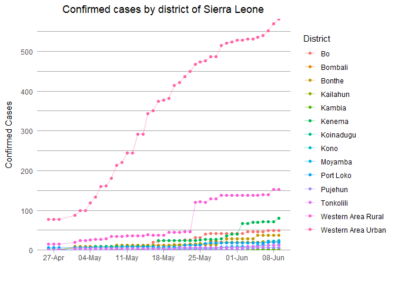

```r
# Amend ggplot2 theme
theme_parts <- theme_minimal() +
  theme(
    panel.grid.minor.x = element_blank(),
    panel.grid.major.x = element_blank(),
    panel.grid.minor.y = element_line(size = .1, color = "darkgrey"),
    panel.grid.major.y = element_line(size = .1, color = "darkgrey"),
    axis.ticks.x = element_line(color = "darkgrey"),
    axis.title.x = element_text(margin = margin(t = 10)),
    axis.title.y = element_text(margin = margin(r = 10)),
    plot.title = element_text(hjust = 0.5)
  )

# Plot the data as time series for each district
cv_district %>% mutate(district = factor(district)) %>% ggplot(aes(date, confirmed_cases, col=district)) +
  geom_line(alpha = 0.5) +
  geom_point() +
  theme_minimal() +
  labs(title = "Confirmed cases by district of Sierra Leone", x = "", y = "Confirmed Cases", col = "District") +
  scale_x_date(date_breaks = "weeks" , date_labels = "%d-%b") +
  scale_y_continuous(limits = c(0, NA), expand = expand_scale(add = c(0, 0.03))) +
  theme_parts
```

I quickly perform some checks to ensure that the dataset makes sense:

```r
dup <- cv_district %>% group_by(date, district) %>% count() %>% pull(n)
dup <- sum(dup[dup != 1])
cat("The dataset contains", dup, "duplicate date-district pairs; for each district, each date appears once or not at all.\n")
```

```
## The dataset contains 0 duplicate date-district pairs; for each district, each date appears once or not at all.
```

```r
rm("dup")
```

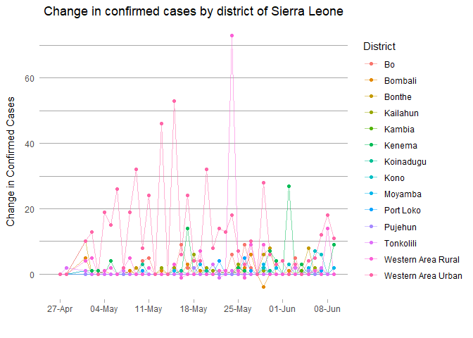

```r
diff <- cv_district %>%
  group_by(district) %>%
  arrange(district, date) %>%
  mutate(diff = confirmed_cases - lag(confirmed_cases))

diff %>%
  ggplot(aes(date, diff, col=district)) +
  geom_line(alpha = 0.5) +
  geom_point() +
  theme_minimal() +
  labs(title = "Change in confirmed cases by district of Sierra Leone", x = "", y = "Change in Confirmed Cases", col = "District") +
  scale_x_date(date_breaks = "weeks" , date_labels = "%d-%b") +
  theme_parts
```

```r
diff %>% filter(diff < 0) %>% kable() %>% kable_styling(full_width=F, font_size=11)
```

| date | district | confirmed_cases | diff |
| --- | --- | --- | --- |
| 2020-05-29 | Bombali | 19 | -4 |
| 2020-05-22 | Tonkolili | 6 | -1 |
| 2020-05-16 | Western Area Rural | 38 | -1 |
| 2020-05-26 | Western Area Rural | 120 | -1 |

```r
rm("diff")
```

Rather than amending the data to deal with downward revisions to the cumulative figures, I instead add a new dummy variable to indicate a `decrease` has occurred. The user of the dataset can decide how to treat downward revisions.

```r
cv_district <- cv_district %>%
  group_by(district) %>%
  arrange(district, date) %>%
  mutate(diff = confirmed_cases - lag(confirmed_cases)) %>%
  mutate(decrease = ifelse(diff < 0, 1, 0)) %>%
  mutate(decrease = ifelse(is.na(decrease), 0, decrease)) %>%
  select(date, district, confirmed_cases, decrease) %>%
  ungroup()
```

I expand the time series to include all dates between the first and last recorded date, even those on which no data are reported:

```r
# Create tibble for full period for which data on cases are available
cv_district <- expand_grid(date = seq(min(cv_district$date), max(cv_district$date), by="days"),
                             district = distinct(cv_district, district) %>% pull(district)) %>% left_join(cv_district, by = c("date", "district")) %>% arrange(date, district)
```

We end up with a tibble with 4 different columns:

- `date`: Date of reporting.
- `district`: District of Sierra Leone (based on pre-2017 administrative boundaries)
- `confirmed_cases`: Cumulative number of confirmed coronavirus cases; NA if no data reported
- `decrease`: Dummy variable indicating whether the number of reported cases has been revised downwards. NA if no reported cases on that date; 1 if there is a decrease from the last reported cases; 0 otherwise

Finally, we export the tibble as a csv:

```r
write_csv(cv_district, file.path(OUTPUT_PATH, CV_DISTRICT_OUT))
```

## 4.3 District-Level Demographics Data

The following code prepares the district-level demographics data:

```r
# Import district-level demographics data
pop_district <- read_csv(file.path(INPUT_PATH, POP_DISTRICT))

# Rename variables to lower case and no spaces
pop_district <- pop_district %>%
  gather(stat, value, -c(District, `D Code`)) %>%
  rename(d_code = `D Code`,
         district = District) %>%
  mutate(stat = str_to_lower(str_replace_all(stat, " ", "_"))) %>%
  spread(stat, value) %>%
  select(district, d_code, d_id, total_pop, pop_share, t_male, t_female, s_ratio, t_rural, t_urban, prop_urban, t_h_pop, h_male, h_female, t_i_pop, i_male, i_female, working_pop, depend_pop)
```

We export the tibble as a csv:

```r
write_csv(pop_district, file.path(OUTPUT_PATH, POP_DISTRICT_OUT))
```

## 4.4 District-Level Main Source of Information Data

The following code prepares the district-level main source of information data:

```r
# Import district-level main source of information data
info_district <- read_csv(file.path(INPUT_PATH, INFO_DISTRICT)) %>% select(-X14) %>% slice(1:14)

# Rename variables to all lower case and replacing "/" and spaces with underscores
info_district <- info_district %>% gather(stat, value, -c(District, `D Code`, `Church/Mosque`)) %>%
  rename(d_code = `D Code`,
         district = District) %>%
  mutate(stat = str_to_lower(str_replace_all(stat, " ", "_"))) %>%
  spread(stat, value) %>%
  rename(church_or_mosque = `Church/Mosque`) %>%
  select(district, d_code, d_id, total_household, radio, television, print_media, post_mail, hand_mail, social_media, word_mouth, church_or_mosque, other)
```

I confirm that the 14 `district`, `d_code` and `d_id` match those in the demographics dataset.

```r
test <- info_district %>% select(district, d_code, d_id) %>% left_join(pop_district %>% select("district", "d_code", "d_id"), by = "district") %>% mutate(check = d_code.x == d_code.y & d_id.x == d_id.y) %>% pull(check) %>% sum() == 14
cat("`district`, `d_code` and `d_id` match in the demographics and information sources datasets:", test)
```

```
## `district`, `d_code` and `d_id` match in the demographics and information sources datasets: TRUE
```

```r
rm("test")
```

I check that the total number of households matches the sum across the different sources of information:

```r
info_district %>% mutate(total_household_check = radio + television + print_media + post_mail + hand_mail + social_media + word_mouth + church_or_mosque + other) %>% mutate(check = total_household_check - total_household) %>% select(district, total_household, total_household_check, check) %>% kable() %>% kable_styling(full_width=F, font_size=11)
```

| district | total_household | total_household_check | check |
| --- | --- | --- | --- |
| Bo | 102723 | 102723 | 0 |
| Bombali | 105902 | 105902 | 0 |
| Bonthe | 32538 | 32538 | 0 |
| Kailahun | 83348 | 83348 | 0 |
| Kambia | 53826 | 53826 | 0 |
| Kenema | 111734 | 111734 | 0 |
| Koinadugu | 56108 | 56108 | 0 |
| Kono | 86119 | 86119 | 0 |
| Moyamba | 61880 | 61880 | 0 |
| Port Loko | 111701 | 111701 | 0 |
| Pujehun | 51514 | 51514 | 0 |
| Tonkolili | 86840 | 86840 | 0 |
| Western Area Rural | 91284 | 91284 | 0 |
| Western Area Urban | 22995 | 229951 | 206956 |

It seems clear that the `total_household` is incorrect for the Western Area Urban. We replace the value with `229951`, in other words re-including the missing `1`:

```r
info_district <- info_district %>% mutate(total_household = ifelse(district == "Western Area Urban", 229951, total_household))
```

We have the following columns:

1. `district`: District of Sierra Leone (pre-2017)
2. `d_code`: District code
3. `d_id`: District id
4. `total_household`: Total number of households (corrected)
5. `radio`: Number of households with radio as main source of information
6. `television`: Number of households with television as main source of information
7. `print_media`: Number of households with print media as main source of information
8. `post_mail`: Number of households with post mail as main source of information
9. `hand_mail`: Number of households with hand mail as main source of information
10. `social_media`: Number of households with social media as main source of information
11. `word_mouth`: Number of households with word of mouth as main source of information
12. `church_or_mosque`: Number of households with church or mosque as main source of information
13. `other`: Number of households with another main source of information, not already listed

We export the tibble as a csv:

```r
write_csv(info_district, file.path(OUTPUT_PATH, INFO_DISTRICT_OUT))
```

# 5 Country-Level Data

The following code prepares the country-level coronavirus data:

```r
# Import national-level coronavirus data
cv_national <- read_csv(file.path(INPUT_PATH, CV_NATIONAL))

# Amend variable names
colnames(cv_national) <- str_replace_all(colnames(cv_national), " ", "_") %>% str_to_lower(.)
cv_national <- cv_national %>% rename(new_cases = new_case)

# Convert datetimes to dates
cv_national <- cv_national %>% mutate(date = make_date(year(date), month(date), day(date)))
```

We observe the following issues in the data:

- There are two observations for 1 May 2020 with the same time stamp
- The number of `confirmed_cases` decreases and increases again
- There are NAs, for example for `at_isolation_centres`

The user of the data will need to decide how to treat these issues.

```r
cv_national %>% head() %>% kable() %>% kable_styling(full_width=F, font_size=11)
```

| date | new_cases | confirmed_cases | at_isolation_centres | recovered | death | in_quarantine | out_of_quarantine | female | male |
| --- | --- | --- | --- | --- | --- | --- | --- | --- | --- |
| 2020-04-26 | 7 | 79 | NA | 10 | 3 | 889 | 93 | 45 | 58 |
| 2020-04-27 | 6 | 5 | NA | 10 | 4 | 1187 | 99 | 49 | 50 |
| 2020-04-28 | 5 | 8 | NA | 12 | 4 | 1192 | 104 | 49 | 51 |
| 2020-04-29 | 5 | 104 | 88 | 12 | 4 | 1192 | 1139 | 49 | 51 |
| 2020-04-30 | 12 | 116 | 98 | 14 | 4 | 1166 | 1426 | 55 | 61 |
| 2020-05-01 | 8 | 124 | 96 | 21 | 7 | 1166 | 1448 | 58 | 68 |

We export the tibble as a csv:

```r
write_csv(cv_national, file.path(OUTPUT_PATH, CV_NATIONAL_OUT))
```